# Top Ranked City

Ryan Nguyen Kimaya Rane Rodridgo Vasquez

10/31/2017

```r
##devtools::install_github("patilv/gudatavizfa17",auth_token="d183f669695ecf83cd0bf2875db10f9fe195acde")
##library(gudatavizfa17)
##opendataviz()
```

```r
library(ggplot2)
library(dplyr)
library(tidyr)
library(googleVis)
```

## 1. Please look at relationships between different variables and identify variables that appear to be strongly related to having a higher rank in the survey.

```r
## Making a new dataset compiling all the variables and values
bcities=gudatavizfa17::bcities
facetcities=gather(bcities, "Variable", "Values", 1,3:13)
## Taking out "City" as a variable
str(facetcities)
```

```
## 'data.frame':    600 obs. of  5 variables:
##  $ Rank    : int  50 49 48 47 46 45 44 43 42 41 ...
##  $ lon     : num  -118.2 -149.9 -96 -90.2 -81.7 ...
##  $ lat     : num  34.1 61.2 41.3 38.6 41.5 ...
##  $ Variable: chr  "City" "City" "City" "City" ...
##  $ Values  : chr  "Los Angeles" "Anchorage" "Omaha" "St. Louis" ...
```

```r
facetcities=facetcities[facetcities$Variable!="City",]
```

```r
## Converting values that were categorized as characters back to numeric values
facetcities$Values=as.numeric(facetcities$Values)
```

## Facet Wrap of the variables plotted against Rank

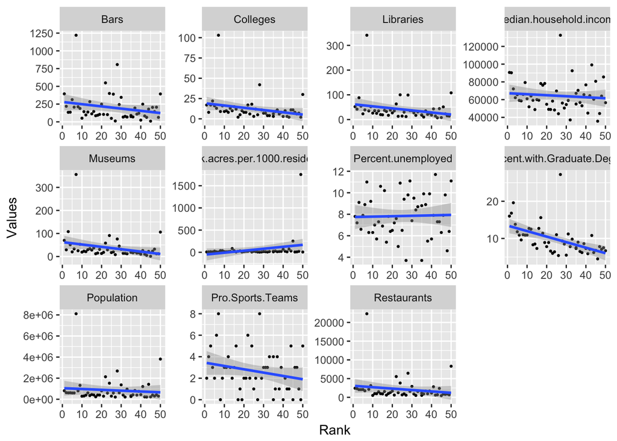

```r
ggplot(facetcities,aes(x=Rank,y=Values)) + geom_point(size=.5)+ facet_wrap(~Variable, scales = "free")+geom_smooth(method="lm")
```

When identifying varibales that strongly correlate to rank, the variables that immediately stand out are number of bars, number of colleges, number of Museums, percent with graduate degree, number of pro sports teams, and restuarants. The cities that are ranked in the top 10 on average have more bars, colleges, museums, and restaurants. However, the strongest factors for rank seem to be percent with graduate degree, becuase it has the most significant slope. The cities ranked in top 10 on average have between 10-20 percent with a graduate degree where as cities ranked closer to the bottom have less than 10 percent with a graduate degree. Factors that very weakly correlate with rank are libraries – the more libraries the better the rank, population – the higher the population the better the rank, this could be becuase more people want to move to better ranked cities, and park acres per 1000 residents– the worse ranks have more park acrs per 1000 residents. These graphs show a line of best fit with a small slope. Percent unemployed and median household income seems to have no correlation to rank becuase the slope of the line of best fit is essentially zero. Thus, the strongest factor is percent with a graduate degree.

##2. Plot the cities on a map of the US.

```r
names(bcities)[4]="Bars"
names(bcities)[3]="Pop"
names(bcities)[8]="ProSpo"
```

```r
MMap <- gvisGeoChart(bcities, locationvar = "City", options=list(region="US", displayMode="markers", resolution="provinces", width=600, height=400))
plot(MMap)
```

[output not shown]

##3. Identify the States in which these cities lie and then develop a choropleth that colors different states based on the number of cities that are present in each State.

##Add in States

```r
cityState=bcities%>%group_by(City)%>%summarize(Rank, Bars)
cityState$State[cityState$City == "Arlington"] <- "Texas"
cityState$State[cityState$City == "Anchorage"] <- "Alaska"
cityState$State[cityState$City == "Seattle"] <- "Washington"
cityState$State[cityState$City == "Washington"] <- "Utah"
cityState$State[cityState$City == "Boston"] <- "Massachusetts"
cityState$State[cityState$City == "Portland"] <- "Oregon"
cityState$State[cityState$City == "Denver"] <- "Colorado"
cityState$State[cityState$City == "Austin"] <- "Texas"
cityState$State[cityState$City == "San Diego"] <- "California"
cityState$State[cityState$City == "St. Paul"] <- "Minnesota"
cityState$State[cityState$City == "Pittsburgh"] <- "Pennsylvania"
cityState$State[cityState$City == "Minneapolis"] <- "Minnesota"
cityState$State[cityState$City == "Nashvile"] <- "Tennessee"
cityState$State[cityState$City == "New Orleans"] <- "Louisiana"
cityState$State[cityState$City == "Kansas City"] <- "Missouri"
cityState$State[cityState$City == "Atlanta"] <- "Georgia"
cityState$State[cityState$City == "Madison"] <- "Alabama"
cityState$State[cityState$City == "Raleigh"] <- "North Carolina"
cityState$State[cityState$City == "Honolulu"] <- "Hawaii"
cityState$State[cityState$Rank == "20"] <- "Ohio"
cityState$State[cityState$City == "Cincinatti"] <- "Ohio"
cityState$State[cityState$City == "Houston"] <- "Texas"
cityState$State[cityState$City == "Oklahoma City"] <- "Oklahoma"
cityState$State[cityState$City == "Philadelphia"] <- "Pennsylvania"
cityState$State[cityState$City == "Lexington"] <- "Kentucky"
cityState$State[cityState$City == "Milwaukee"] <- "Wisconsin"
cityState$State[cityState$City == "Arlington"] <- "Texas"
cityState$State[cityState$City == "Chicago"] <- "Illinois"
cityState$State[cityState$City == "Baltimore"] <- "Maryland"
cityState$State[cityState$City == "San Antonio"] <- "Texas"
cityState$State[cityState$City == "Oakland"] <- "California"
cityState$State[cityState$City == "Rochester"] <- "New York"
cityState$State[cityState$City == "San Jose"] <- "California"
cityState$State[cityState$City == "Tampa"] <- "Florida"
cityState$State[cityState$City == "Lincoln"] <- "Nebraska"
cityState$State[cityState$City == "Colorado Springs"] <- "Colorado"
cityState$State[cityState$City == "Indianapolis"] <- "Indiana"
cityState$State[cityState$City == "Tulsa"] <- "Oklahoma"
cityState$State[cityState$City == "Charlotte"] <- "North Carolina"
cityState$State[cityState$City == "Virgina Beach"] <- "Virgina"
cityState$State[cityState$Rank == "41"] <- "Texas"
cityState$State[cityState$Rank == "44"] <- "Phoenix"
cityState$State[cityState$Rank == "9"] <- "California"
cityState$State[cityState$Rank == "1"] <- "California"
cityState$State[cityState$Rank == "40"] <- "Virginia"
cityState$State[cityState$Rank == "35"] <- "Florida"
cityState$State[cityState$City == "Reno"] <- "Nevada"
cityState$State[cityState$City == "Scottsdale"] <- "Arizona"
cityState$State[cityState$City == "Pheonix"] <- "Arizonia"
cityState$State[cityState$City == "Chesapeake"] <- "Virgina"
cityState$State[cityState$City == "Cleveland"] <- "Ohio"
cityState$State[cityState$City == "St. Louis"] <- "Missouri"
cityState$State[cityState$City == "Omaha"] <- "Nebraska"
cityState$State[cityState$City == "Anchorage"] <- "Alaska"
cityState$State[cityState$City == "Los Angeles"] <- "California"
cityState$State[cityState$City == "New York"] <- "New York"
```

```r
cityState = cityState %>% group_by(State) %>% summarise(Count = n())
str(cityState)
```

```
## Classes 'tbl_df', 'tbl' and 'data.frame':    32 obs. of  2 variables:
##  $ State: chr  "Alabama" "Alaska" "Arizona" "California" ...
##  $ Count: int  1 1 1 5 2 2 1 1 1 1 ...
```

```r
GeoStates <- gvisGeoChart(cityState, "State","Count",
                          options=list(region="US", displayMode="regions", resolution="provinces",
                                       width=600, height=400))
plot(GeoStates)
```

[output not shown]